# AFL Round Summary

## Geelong Cats v Brisbane Lions

No bet 2026-07-02 19:30 | GMHBA Stadium

Model line / market **-14.0 vs n/a** Edge: No line ( No bet )

Model total / market **185.2 vs n/a** Edge: No total ( No bet )

Total volatility **Normal volatility | 0.88x comp avg; SD 23.7** Alt watch: No alt watch

Margin volatility **Normal volatility | 1.06x comp avg; SD 38.7** Based on observed scoring and margins.

**Weather:** Weather/environment impact: total -0.2, line -0.0. Current scoring environment n/a vs historical n/a.

No clear model edge at current market numbers. Recent form below uses only current-season games before this fixture.

### Geelong Cats

Scoreboard: 88.2 scored / 80.5 conceded.  
Expectation check: -12.6 vs model, -4.0 vs market. Higher is better.  
Last 4 totals: -22.4 vs weather-adjusted model, -7.0 vs market. Games are landing below expectation.

- **Lineup impact:** line n/a , total n/a

### Brisbane Lions

Scoreboard: 106.2 scored / 85.2 conceded.  
Expectation check: +6.4 vs model, +9.0 vs market. Higher is better.  
Last 4 totals: +6.5 vs weather-adjusted model, +6.5 vs market. Games are landing above expectation.

- **Lineup impact:** included in match-level delta above.

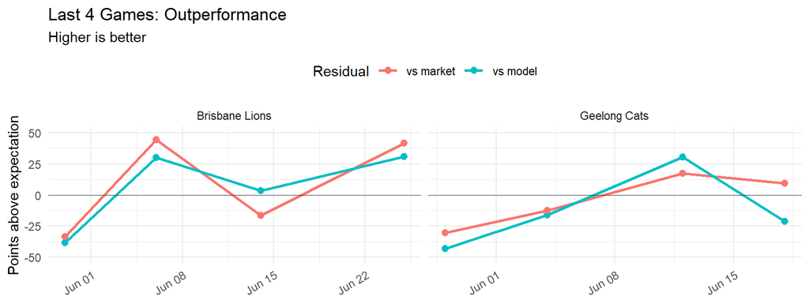

### Last 4 Games: Full Game Totals

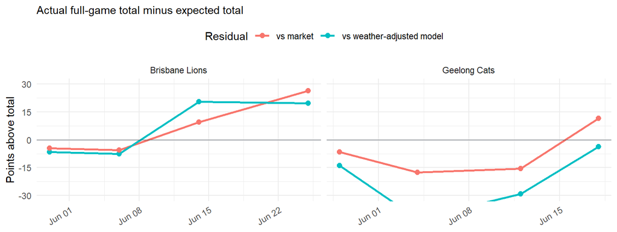

### Goal Watch

**Brisbane Lions :** Logan Morris | 1+ 1.20 , 2+ 1.88 , 3+ 3.79 .

**Brisbane Lions :** Charlie Cameron | 1+ 1.28 , 2+ 2.21 , 3+ 5.04 .

**Brisbane Lions :** Zac Bailey | 1+ 1.40 , 2+ 2.79 , 3+ 7.50 .

**Geelong Cats :** Jeremy Cameron | 1+ 1.07 , 2+ 1.32 , 3+ 1.93 .

**Geelong Cats :** Shannon Neale | 1+ 1.22 , 2+ 1.98 , 3+ 4.14 .

**Geelong Cats :** Oliver Henry | 1+ 1.27 , 2+ 2.19 , 3+ 4.93 .

## West Coast Eagles v Adelaide Crows

No bet 2026-07-03 18:10 | Optus Stadium

Model line / market **+29.9 vs n/a** Edge: No line ( No bet )

Model total / market **163.9 vs n/a** Edge: No total ( No bet )

Total volatility **Normal volatility | 0.90x comp avg; SD 24.2** Alt watch: No alt watch

Margin volatility **Normal volatility | 1.05x comp avg; SD 38.4** Based on observed scoring and margins.

**Weather:** Weather/environment impact: total +0.0, line +0.0. Current scoring environment n/a vs historical n/a.

No clear model edge at current market numbers. Recent form below uses only current-season games before this fixture.

### West Coast Eagles

Scoreboard: 73.2 scored / 80.8 conceded.  
Expectation check: +9.4 vs model, +3.5 vs market. Higher is better.  
Last 4 totals: -4.8 vs weather-adjusted model, -10.8 vs market. Games are landing below expectation.

- **Lineup impact:** line n/a , total n/a

### Adelaide Crows

Scoreboard: 86.5 scored / 74.2 conceded.  
Expectation check: +12.7 vs model, +6.0 vs market. Higher is better.  
Last 4 totals: -23.5 vs weather-adjusted model, -11.2 vs market. Games are landing below expectation.

- **Lineup impact:** included in match-level delta above.

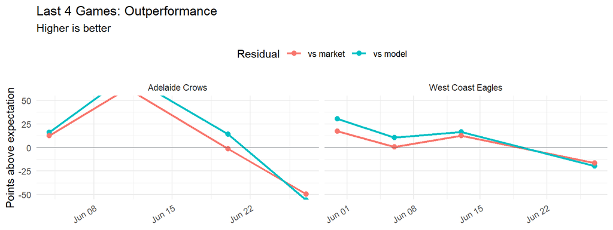

### Last 4 Games: Full Game Totals

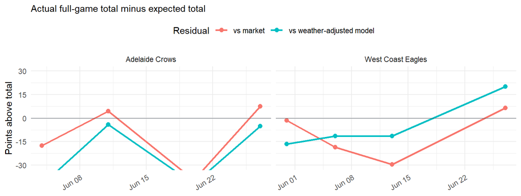

### Goal Watch

**Adelaide Crows :** Riley Thilthorpe | 1+ 1.19 , 2+ 1.83 , 3+ 3.58 .

**Adelaide Crows :** Taylor Walker | 1+ 1.19 , 2+ 1.83 , 3+ 3.61 .

**Adelaide Crows :** Josh Rachele | 1+ 1.23 , 2+ 1.99 , 3+ 4.17 .

**West Coast Eagles :** Jake Waterman | 1+ 1.33 , 2+ 2.48 , 3+ 6.14 .

**West Coast Eagles :** Jobe Shanahan | 1+ 1.67 , 2+ 4.31 , 3+ 15.39 .

**West Coast Eagles :** Milan Murdock | 1+ 1.87 , 2+ 5.58 , 3+ 23.42 .

## Sydney Swans v Western Bulldogs

No bet 2026-07-03 19:40 | SCG

Model line / market **-10.1 vs n/a** Edge: No line ( No bet )

Model total / market **179.7 vs n/a** Edge: No total ( No bet )

Total volatility **Normal volatility | 0.90x comp avg; SD 24.2** Alt watch: No alt watch

Margin volatility **High volatility | 1.22x comp avg; SD 44.6** Based on observed scoring and margins.

**Weather:** Weather/environment impact: total +0.0, line +0.0. Current scoring environment n/a vs historical n/a.

No clear model edge at current market numbers. Recent form below uses only current-season games before this fixture.

### Sydney Swans

Scoreboard: 112.5 scored / 93.5 conceded.  
Expectation check: -4.4 vs model, -5.8 vs market. Higher is better.  
Last 4 totals: +23.9 vs weather-adjusted model, +26.5 vs market. Games are landing above expectation.

- **Lineup impact:** line n/a , total n/a

### Western Bulldogs

Scoreboard: 80.2 scored / 86.5 conceded.  
Expectation check: -20.4 vs model, -6.0 vs market. Higher is better.  
Last 4 totals: -24.9 vs weather-adjusted model, -12.8 vs market. Games are landing below expectation.

- **Lineup impact:** included in match-level delta above.

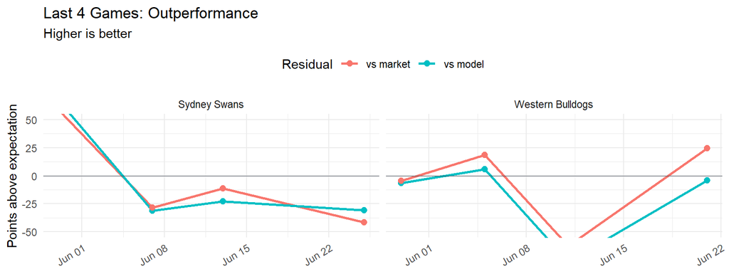

### Last 4 Games: Full Game Totals

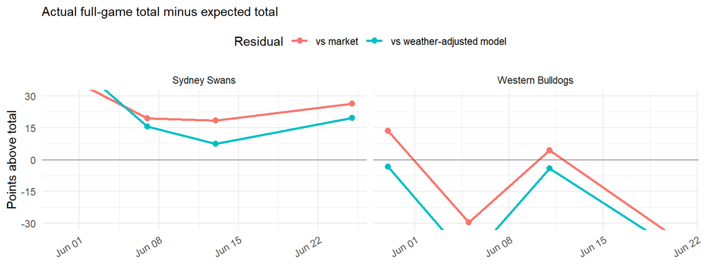

### Goal Watch

**Sydney Swans :** Charlie Curnow | 1+ 1.15 , 2+ 1.68 , 3+ 3.07 .

**Sydney Swans :** Joel Amartey | 1+ 1.29 , 2+ 2.29 , 3+ 5.34 .

**Sydney Swans :** Logan McDonald | 1+ 1.34 , 2+ 2.52 , 3+ 6.31 .

**Western Bulldogs :** Aaron Naughton | 1+ 1.16 , 2+ 1.71 , 3+ 3.18 .

**Western Bulldogs :** Rhylee West | 1+ 1.47 , 2+ 3.14 , 3+ 9.15 .

**Western Bulldogs :** Will Lewis | 1+ 1.48 , 2+ 3.22 , 3+ 9.51 .

## Hawthorn v Melbourne

No bet 2026-07-04 13:15 | UTAS Stadium

Model line / market **-16.4 vs n/a** Edge: No line ( No bet )

Model total / market **173.0 vs n/a** Edge: No total ( No bet )

Total volatility **Normal volatility | 0.97x comp avg; SD 26.2** Alt watch: No alt watch

Margin volatility **Normal volatility | 0.86x comp avg; SD 31.4** Based on observed scoring and margins.

**Weather:** Weather/environment impact: total +0.0, line +0.0. Current scoring environment n/a vs historical n/a.

No clear model edge at current market numbers. Recent form below uses only current-season games before this fixture.

### Hawthorn

Scoreboard: 99.8 scored / 80.8 conceded.  
Expectation check: +11.8 vs model, +4.2 vs market. Higher is better.  
Last 4 totals: -8.2 vs weather-adjusted model, +3.8 vs market. Games are landing below expectation.

- **Lineup impact:** line n/a , total n/a

### Melbourne

Scoreboard: 77.5 scored / 80.8 conceded.  
Expectation check: -11.1 vs model, -4.2 vs market. Higher is better.  
Last 4 totals: -23.8 vs weather-adjusted model, -19.0 vs market. Games are landing below expectation.

- **Lineup impact:** included in match-level delta above.

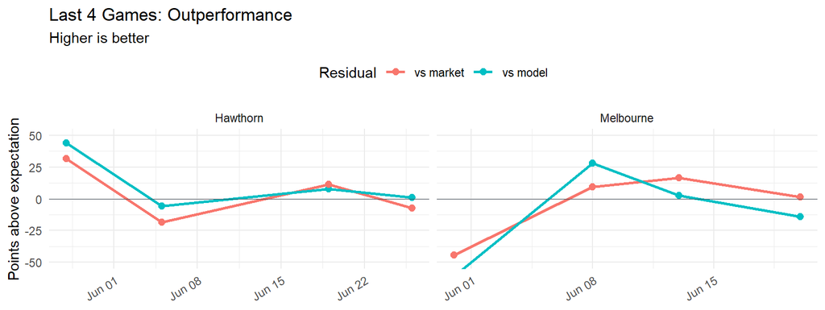

### Last 4 Games: Full Game Totals

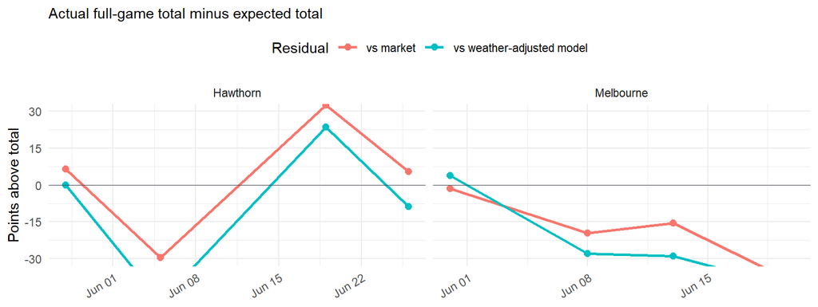

### Goal Watch

**Hawthorn :** Nick Watson | 1+ 1.14 , 2+ 1.63 , 3+ 2.91 .

**Hawthorn :** Mabior Chol | 1+ 1.18 , 2+ 1.80 , 3+ 3.51 .

**Hawthorn :** Mitch Lewis | 1+ 1.23 , 2+ 2.02 , 3+ 4.28 .

**Melbourne :** Bayley Fritsch | 1+ 1.43 , 2+ 2.97 , 3+ 8.31 .

**Melbourne :** Jake Melksham | 1+ 1.47 , 2+ 3.15 , 3+ 9.17 .

**Melbourne :** Kysaiah Pickett | 1+ 1.48 , 2+ 3.21 , 3+ 9.48 .

## Greater Western Sydney v Fremantle

No bet 2026-07-04 13:35 | Corroboree Group Oval Manuka

Model line / market **+15.1 vs n/a** Edge: No line ( No bet )

Model total / market **165.9 vs n/a** Edge: No total ( No bet )

Total volatility **High volatility | 1.24x comp avg; SD 33.4** Alt watch: No alt watch

Margin volatility **Normal volatility | 1.02x comp avg; SD 37.3** Based on observed scoring and margins.

**Weather:** Weather/environment impact: total +0.0, line +0.0. Current scoring environment n/a vs historical n/a.

No clear model edge at current market numbers. Recent form below uses only current-season games before this fixture.

### Greater Western Sydney

Scoreboard: 88.5 scored / 87.5 conceded.  
Expectation check: -5.9 vs model, -0.5 vs market. Higher is better.  
Last 4 totals: -7.1 vs weather-adjusted model, -6.8 vs market. Games are landing below expectation.

- **Lineup impact:** line n/a , total n/a

### Fremantle

Scoreboard: 109.2 scored / 57.0 conceded.  
Expectation check: +49.0 vs model, +35.8 vs market. Higher is better.  
Last 4 totals: -18.4 vs weather-adjusted model, -11.5 vs market. Games are landing below expectation.

- **Lineup impact:** included in match-level delta above.

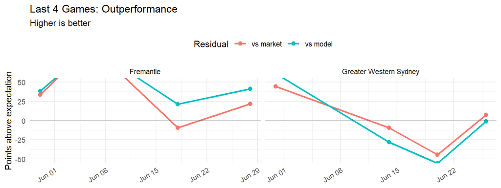

### Last 4 Games: Full Game Totals

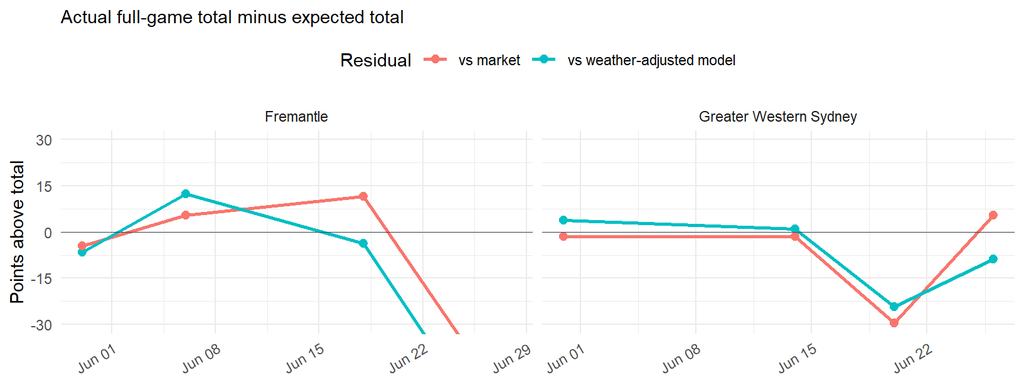

### Goal Watch

**Fremantle :** Josh Treacy | 1+ 1.30 , 2+ 2.32 , 3+ 5.45 .

**Fremantle :** Jye Amiss | 1+ 1.34 , 2+ 2.50 , 3+ 6.22 .

**Fremantle :** Patrick Voss | 1+ 1.35 , 2+ 2.58 , 3+ 6.54 .

**Greater Western Sydney :** Jesse Hogan | 1+ 1.21 , 2+ 1.91 , 3+ 3.88 .

**Greater Western Sydney :** Toby Greene | 1+ 1.28 , 2+ 2.23 , 3+ 5.11 .

**Greater Western Sydney :** Jake Stringer | 1+ 1.31 , 2+ 2.37 , 3+ 5.67 .

## Gold Coast SUNS v Collingwood

No bet 2026-07-04 16:15 | People First Stadium

Model line / market **-9.3 vs n/a** Edge: No line ( No bet )

Model total / market **159.7 vs n/a** Edge: No total ( No bet )

Total volatility **Normal volatility | 1.12x comp avg; SD 30.3** Alt watch: No alt watch

Margin volatility **Normal volatility | 1.01x comp avg; SD 36.8** Based on observed scoring and margins.

**Weather:** Weather/environment impact: total +0.0, line +0.0. Current scoring environment n/a vs historical n/a.

No clear model edge at current market numbers. Recent form below uses only current-season games before this fixture.

### Gold Coast SUNS

Scoreboard: 65.2 scored / 101.0 conceded.  
Expectation check: -27.3 vs model, -23.8 vs market. Higher is better.  
Last 4 totals: -22.2 vs weather-adjusted model, -11.8 vs market. Games are landing below expectation.

- **Lineup impact:** line n/a , total n/a

### Collingwood

Scoreboard: 88.0 scored / 76.0 conceded.  
Expectation check: -15.2 vs model, +1.8 vs market. Higher is better.  
Last 4 totals: -17.7 vs weather-adjusted model, -4.0 vs market. Games are landing below expectation.

- **Lineup impact:** included in match-level delta above.

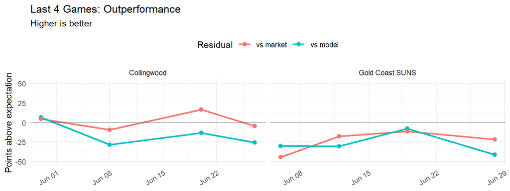

### Last 4 Games: Full Game Totals

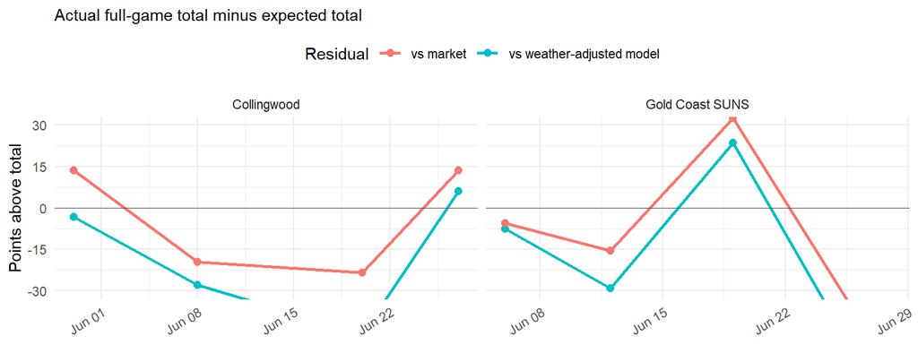

### Goal Watch

**Collingwood :** Tim Membrey | 1+ 1.34 , 2+ 2.52 , 3+ 6.31 .

**Collingwood :** Daniel McStay | 1+ 1.36 , 2+ 2.62 , 3+ 6.76 .

**Collingwood :** Lachie Schultz | 1+ 1.51 , 2+ 3.36 , 3+ 10.24 .

**Gold Coast SUNS :** Ben King | 1+ 1.10 , 2+ 1.44 , 3+ 2.31 .

**Gold Coast SUNS :** Ben Long | 1+ 1.31 , 2+ 2.35 , 3+ 5.60 .

**Gold Coast SUNS :** Jed Walter | 1+ 1.36 , 2+ 2.61 , 3+ 6.71 .

## Richmond v Carlton

No bet 2026-07-04 19:35 | MCG

Model line / market **+22.9 vs n/a** Edge: No line ( No bet )

Model total / market **158.6 vs n/a** Edge: No total ( No bet )

Total volatility **Normal volatility | 0.98x comp avg; SD 26.4** Alt watch: No alt watch

Margin volatility **Normal volatility | 0.86x comp avg; SD 31.4** Based on observed scoring and margins.

**Weather:** Weather/environment impact: total +0.0, line +0.0. Current scoring environment n/a vs historical n/a.

No clear model edge at current market numbers. Recent form below uses only current-season games before this fixture.

### Richmond

Scoreboard: 64.0 scored / 116.0 conceded.  
Expectation check: -14.7 vs model, -9.8 vs market. Higher is better.  
Last 4 totals: +9.9 vs weather-adjusted model, +2.8 vs market. Games are landing above expectation.

- **Lineup impact:** line n/a , total n/a

### Carlton

Scoreboard: 91.2 scored / 70.0 conceded.  
Expectation check: +26.4 vs model, +16.0 vs market. Higher is better.  
Last 4 totals: -11.2 vs weather-adjusted model, -14.8 vs market. Games are landing below expectation.

- **Lineup impact:** included in match-level delta above.

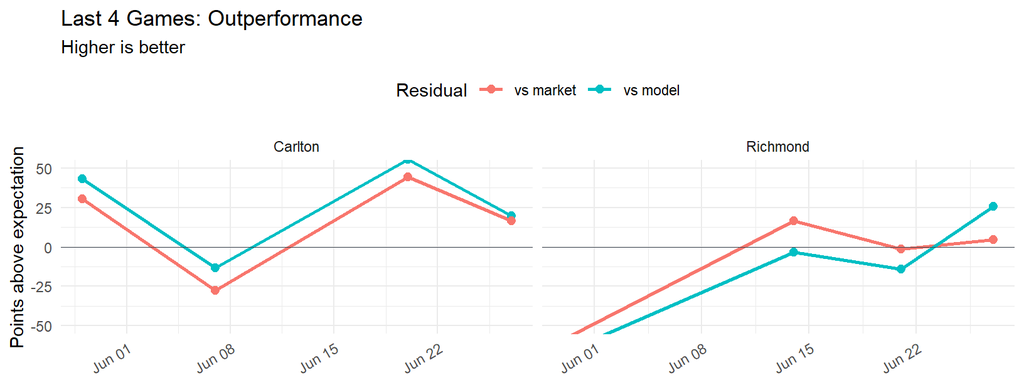

### Last 4 Games: Full Game Totals

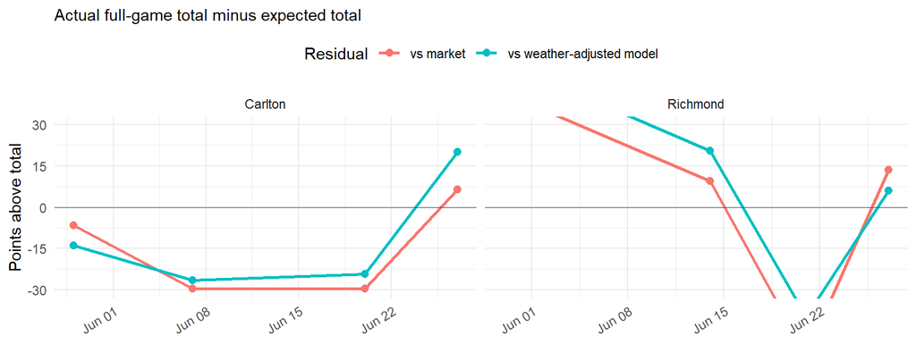

### Goal Watch

**Carlton :** Harry McKay | 1+ 1.24 , 2+ 2.03 , 3+ 4.32 .

**Carlton :** Will Hayward | 1+ 1.35 , 2+ 2.57 , 3+ 6.53 .

**Carlton :** Brodie Kemp | 1+ 1.44 , 2+ 2.99 , 3+ 8.40 .

**Richmond :** Liam Fawcett | 1+ 1.44 , 2+ 3.00 , 3+ 8.46 .

**Richmond :** Jasper Alger | 1+ 1.49 , 2+ 3.28 , 3+ 9.84 .

**Richmond :** Mykelti Lefau | 1+ 1.57 , 2+ 3.74 , 3+ 12.22 .